# Dashboard de avance de programas (versión HTML)

# Avance de programas

Última modificación registrada: 10/11/2026 · Generado el 11/11/2026

**Versión HTML fija.** Este archivo se abre sin R ni Internet, pero no tiene filtros: cada pestaña es una vista calculada al generarlo. Para filtrar por dependencia y tipo, inicia el dashboard interactivo con `shiny::runApp(“dashboard”)`.

## Vista

### Todos los años

Total programas

250

Programas completos

170

Programas con avance

61

Total apoyos

770

Avance programa

93.5%

Avance apoyos

95.0%

Avance global

97.2%

Avance global por dependencia

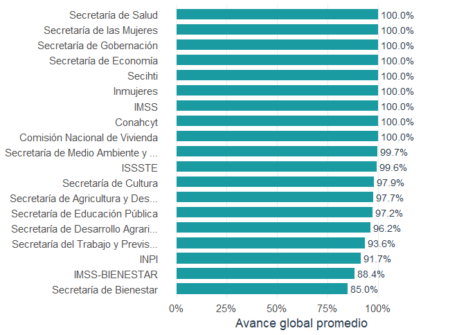

Distribución por estatus

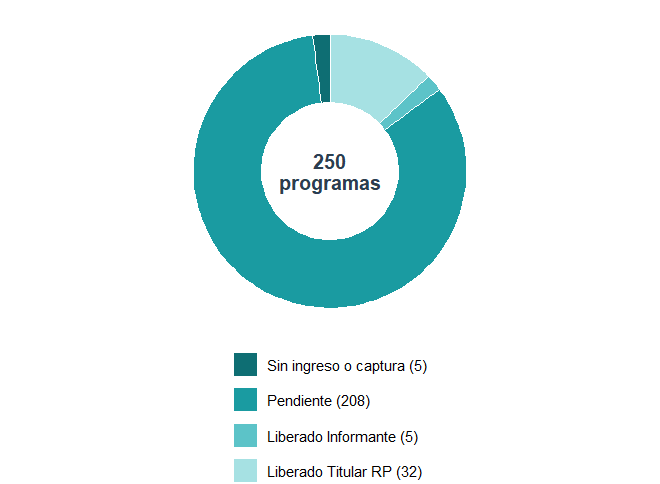

Programas por tipo

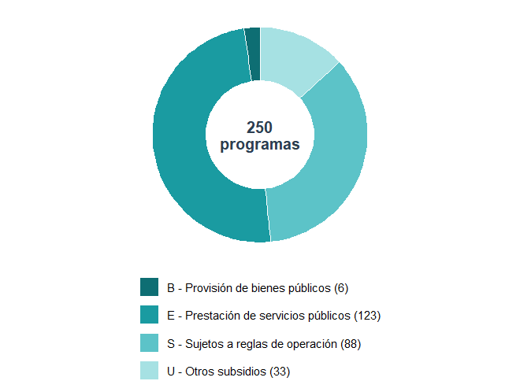

Comparativo por año

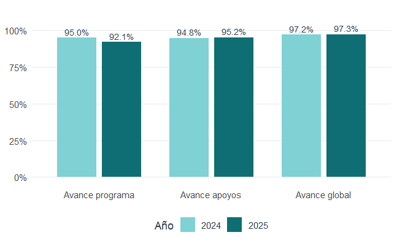

Top 10 dependencias con más programas

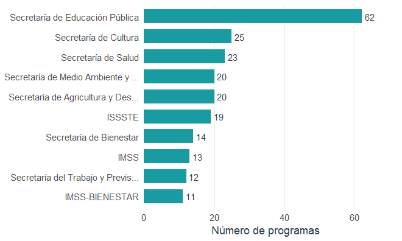

Responsables sin asignar

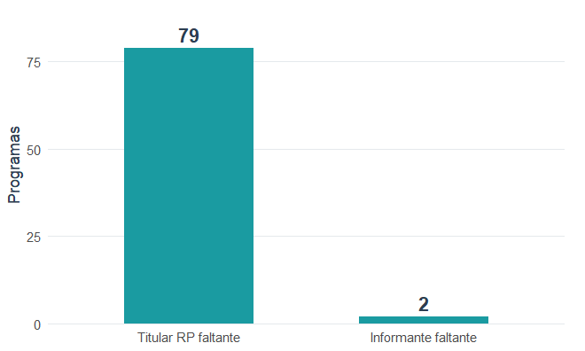

Detalle de programas

| Clave | Programa | Dependencia | Año | Estatus | Avance global | Titular RP |
| --- | --- | --- | --- | --- | --- | --- |
| 15S177 | Programa de Vivienda Social | Comisión Nacional de Vivienda | 2024 | Pendiente | 100.0% | enrique.munoz |
| 15S177 | Programa de Vivienda Social | Comisión Nacional de Vivienda | 2025 | Pendiente | 100.0% | enrique.munoz |
| 38E003 | Investigación científica, desarrollo e innovación | Conahcyt | 2024 | Pendiente | 100.0% | Sin asignar |
| 38S190 | Becas de posgrado y apoyos a la calidad | Conahcyt | 2024 | Pendiente | 100.0% | Sin asignar |
| 38S191 | Sistema Nacional de Investigadores | Conahcyt | 2024 | Pendiente | 100.0% | Sin asignar |
| 51E015 | Investigación y desarrollo tecnológico en salud | ISSSTE | 2024 | Pendiente | 100.0% | yolanda.salyano |
| 51E015 | Investigación y desarrollo tecnológico en salud | ISSSTE | 2025 | Pendiente | 100.0% | yolanda.salyano |
| 51E018 | Suministro de Claves de Medicamentos | ISSSTE | 2024 | Pendiente | 100.0% | emelyn.vazquez |
| 51E018 | Suministro de Claves de Medicamentos | ISSSTE | 2025 | Pendiente | 100.0% | emelyn.vazquez |
| 51E036 | Equidad de Género | ISSSTE | 2024 | Pendiente | 100.0% | gabriela.rioja |
| 51E036 | Equidad de Género | ISSSTE | 2025 | Pendiente | 100.0% | gabriela.rioja |
| 51E042 | Atención a Personas con Discapacidad | ISSSTE | 2024 | Liberado Titular RP | 100.0% | tania.perez |
| 51E042 | Atención a Personas con Discapacidad | ISSSTE | 2025 | Liberado Titular RP | 100.0% | tania.perez |
| 51E043 | Prevención y control de enfermedades | ISSSTE | 2024 | Pendiente | 100.0% | victor.bautista |
| 51E043 | Prevención y control de enfermedades | ISSSTE | 2025 | Pendiente | 100.0% | victor.bautista |
| 51E044 | Atención a la Salud | ISSSTE | 2024 | Pendiente | 100.0% | miriam.martinez |
| 51E044 | Atención a la Salud | ISSSTE | 2025 | Pendiente | 100.0% | miriam.martinez |
| 51E046 | Servicios Deportivos, Culturales, Turísticos y Funerarios | ISSSTE | 2024 | Pendiente | 100.0% | maria.moncada |
| 51E046 | Servicios Deportivos, Culturales, Turísticos y Funerarios | ISSSTE | 2025 | Pendiente | 100.0% | maria.moncada |
| 51E048 | Servicios de Estancias de Bienestar y Desarrollo Infantil | ISSSTE | 2024 | Pendiente | 100.0% | ricardo.jaral |
| 51E048 | Servicios de Estancias de Bienestar y Desarrollo Infantil | ISSSTE | 2025 | Pendiente | 91.7% | ricardo.jaral |
| 51E049 | Servicios Integrales a Pensionados | ISSSTE | 2024 | Pendiente | 100.0% | maria.moncada |
| 51E049 | Servicios Integrales a Pensionados | ISSSTE | 2025 | Pendiente | 100.0% | maria.moncada |
| 51U001 | La Clínica es nuestra | ISSSTE | 2025 | Liberado Informante | 100.0% | canek.serna |
| 19S038 | Programa IMSS-BIENESTAR | IMSS | 2024 | Pendiente | Sin dato | Sin asignar |
| 50E001 | Prevención y control de enfermedades | IMSS | 2024 | Liberado Titular RP | 100.0% | ernesto.krug |
| 50E001 | Prevención y control de enfermedades | IMSS | 2025 | Liberado Titular RP | 100.0% | ernesto.krug |
| 50E003 | Atención a la Salud en el Trabajo | IMSS | 2024 | Pendiente | 100.0% | rebeca.velasco |
| 50E003 | Atención a la Salud en el Trabajo | IMSS | 2025 | Pendiente | 100.0% | rebeca.velasco |
| 50E004 | Investigación y desarrollo tecnológico en salud | IMSS | 2024 | Pendiente | 100.0% | laura.bonifaz |

[output cut: 220 more lines]

### 2024

Total programas

124

Programas completos

88

Programas con avance

29

Total apoyos

389

Avance programa

95.0%

Avance apoyos

94.8%

Avance global

97.2%

Avance global por dependencia

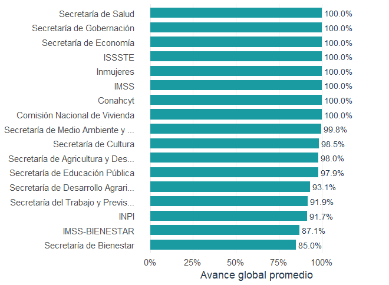

Distribución por estatus

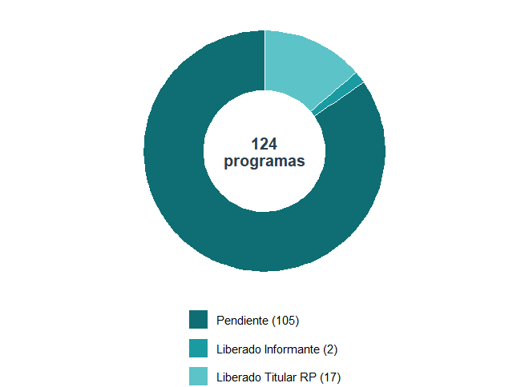

Programas por tipo

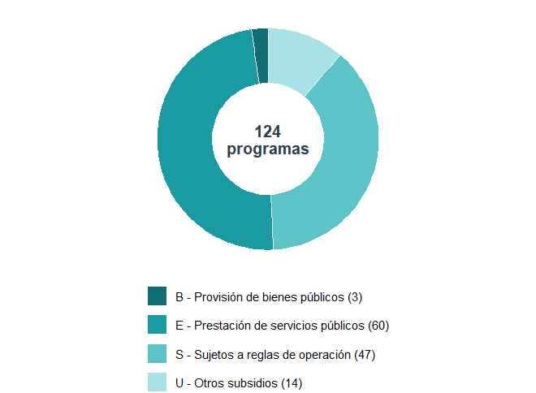

Comparativo por año

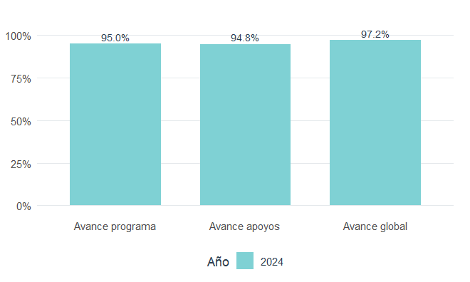

Top 10 dependencias con más programas

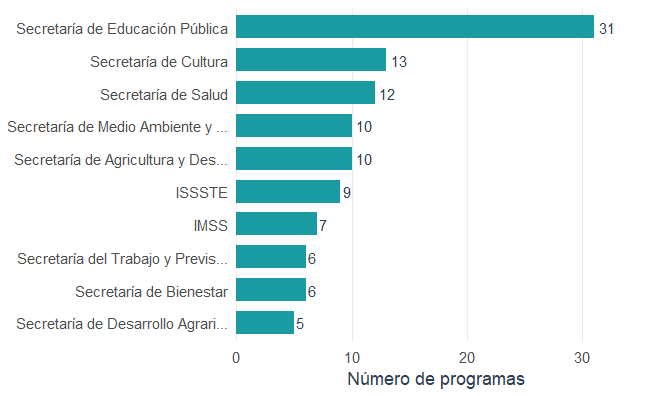

Responsables sin asignar

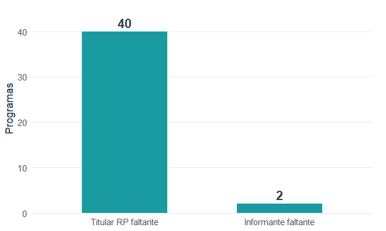

Detalle de programas

| Clave | Programa | Dependencia | Año | Estatus | Avance global | Titular RP |
| --- | --- | --- | --- | --- | --- | --- |
| 15S177 | Programa de Vivienda Social | Comisión Nacional de Vivienda | 2024 | Pendiente | 100.0% | enrique.munoz |
| 38E003 | Investigación científica, desarrollo e innovación | Conahcyt | 2024 | Pendiente | 100.0% | Sin asignar |
| 38S190 | Becas de posgrado y apoyos a la calidad | Conahcyt | 2024 | Pendiente | 100.0% | Sin asignar |
| 38S191 | Sistema Nacional de Investigadores | Conahcyt | 2024 | Pendiente | 100.0% | Sin asignar |
| 51E015 | Investigación y desarrollo tecnológico en salud | ISSSTE | 2024 | Pendiente | 100.0% | yolanda.salyano |
| 51E018 | Suministro de Claves de Medicamentos | ISSSTE | 2024 | Pendiente | 100.0% | emelyn.vazquez |
| 51E036 | Equidad de Género | ISSSTE | 2024 | Pendiente | 100.0% | gabriela.rioja |
| 51E042 | Atención a Personas con Discapacidad | ISSSTE | 2024 | Liberado Titular RP | 100.0% | tania.perez |
| 51E043 | Prevención y control de enfermedades | ISSSTE | 2024 | Pendiente | 100.0% | victor.bautista |
| 51E044 | Atención a la Salud | ISSSTE | 2024 | Pendiente | 100.0% | miriam.martinez |
| 51E046 | Servicios Deportivos, Culturales, Turísticos y Funerarios | ISSSTE | 2024 | Pendiente | 100.0% | maria.moncada |
| 51E048 | Servicios de Estancias de Bienestar y Desarrollo Infantil | ISSSTE | 2024 | Pendiente | 100.0% | ricardo.jaral |
| 51E049 | Servicios Integrales a Pensionados | ISSSTE | 2024 | Pendiente | 100.0% | maria.moncada |
| 19S038 | Programa IMSS-BIENESTAR | IMSS | 2024 | Pendiente | Sin dato | Sin asignar |
| 50E001 | Prevención y control de enfermedades | IMSS | 2024 | Liberado Titular RP | 100.0% | ernesto.krug |
| 50E003 | Atención a la Salud en el Trabajo | IMSS | 2024 | Pendiente | 100.0% | rebeca.velasco |
| 50E004 | Investigación y desarrollo tecnológico en salud | IMSS | 2024 | Pendiente | 100.0% | laura.bonifaz |
| 50E007 | Servicios de guardería | IMSS | 2024 | Pendiente | 100.0% | joanna.cristo |
| 50E011 | Atención a la Salud | IMSS | 2024 | Liberado Titular RP | 100.0% | beatriz.perez |
| 50E012 | Prestaciones sociales | IMSS | 2024 | Pendiente | 100.0% | ivan.camacho |
| 47S010 | Programa para el Adelanto, Bienestar e Igualdad de las Mujeres | Inmujeres | 2024 | Liberado Titular RP | 100.0% | mayra.romo |
| 47S178 | Programa de Apoyo a la Educación Indígena | INPI | 2024 | Pendiente | 91.7% | Sin asignar |
| 47S249 | Programa para el Bienestar Integral de los Pueblos Indígenas | INPI | 2024 | Pendiente | Sin dato | Sin asignar |
| 08B004 | Adquisición de leche nacional | Secretaría de Agricultura y Des… | 2024 | Pendiente | 100.0% | luis.noriega |
| 08E001 | Desarrollo, aplicación de programas educativos e investigación en materia agroalimentaria | Secretaría de Agricultura y Des… | 2024 | Pendiente | 100.0% | joaquin.morales |
| 08E006 | Generación de Proyectos de Investigación | Secretaría de Agricultura y Des… | 2024 | Pendiente | 100.0% | cruz.tapia |
| 08S052 | Programa de Abasto Social de Leche a cargo de Liconsa, S.A. de C.V. | Secretaría de Agricultura y Des… | 2024 | Pendiente | 100.0% | luis.noriega |
| 08S053 | Programa de Abasto Rural a cargo de Diconsa, S.A. de C.V. (DICONSA) | Secretaría de Agricultura y Des… | 2024 | Pendiente | Sin dato | yves.gonzalez |
| 08S263 | Sanidad e Inocuidad Agroalimentaria | Secretaría de Agricultura y Des… | 2024 | Pendiente | 100.0% | francisco.ramirez |
| 08S290 | Precios de Garantía a Productos Alimentarios Básicos | Secretaría de Agricultura y Des… | 2024 | Pendiente | 81.7% | yves.gonzalez |

[output cut: 94 more lines]

### 2025

Total programas

126

Programas completos

82

Programas con avance

32

Total apoyos

381

Avance programa

92.1%

Avance apoyos

95.2%

Avance global

97.3%

Avance global por dependencia

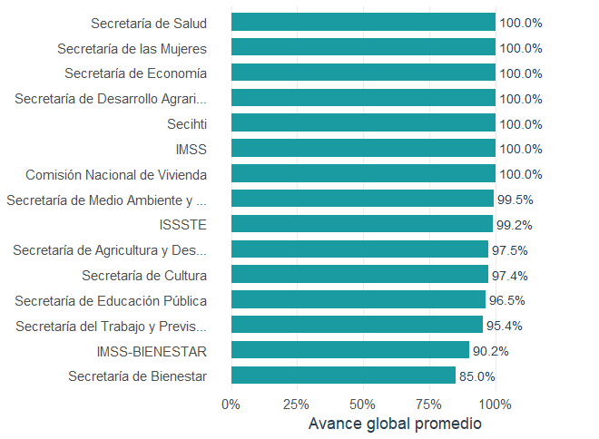

Distribución por estatus

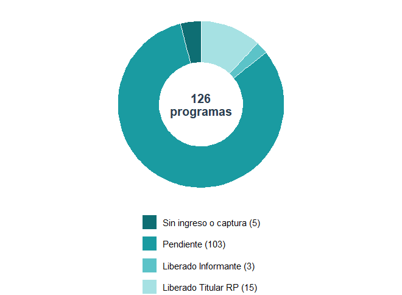

Programas por tipo

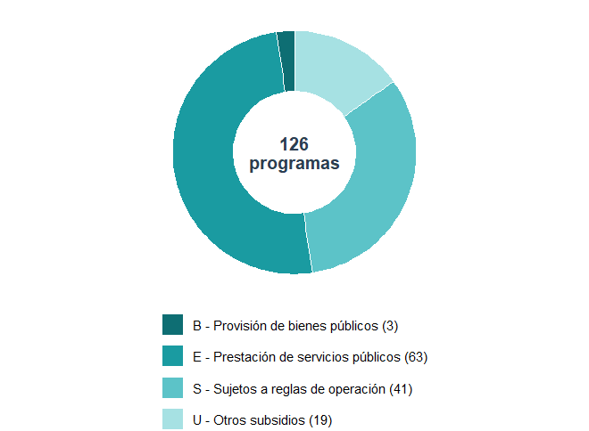

Comparativo por año

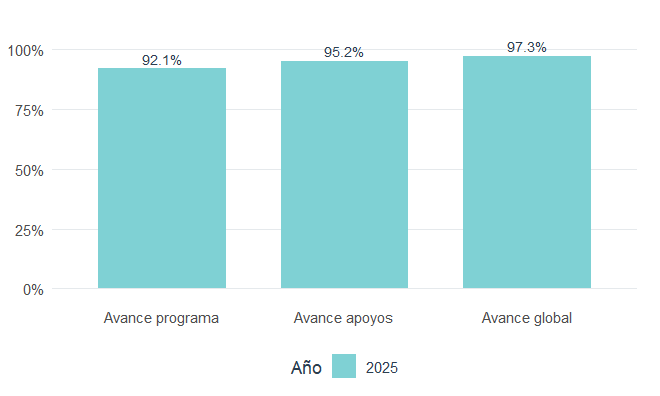

Top 10 dependencias con más programas

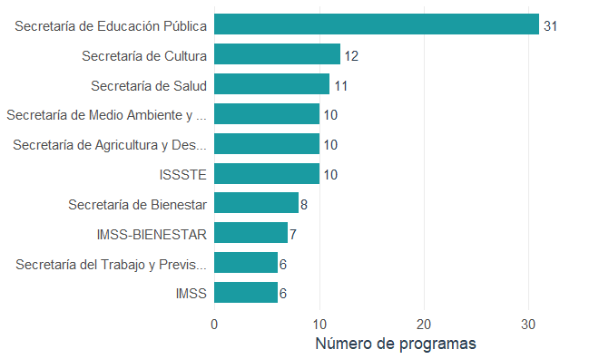

Responsables sin asignar

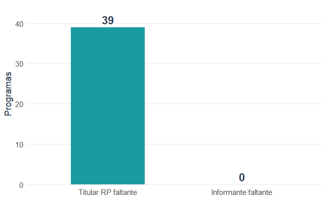

Detalle de programas

| Clave | Programa | Dependencia | Año | Estatus | Avance global | Titular RP |
| --- | --- | --- | --- | --- | --- | --- |
| 15S177 | Programa de Vivienda Social | Comisión Nacional de Vivienda | 2025 | Pendiente | 100.0% | enrique.munoz |
| 51E015 | Investigación y desarrollo tecnológico en salud | ISSSTE | 2025 | Pendiente | 100.0% | yolanda.salyano |
| 51E018 | Suministro de Claves de Medicamentos | ISSSTE | 2025 | Pendiente | 100.0% | emelyn.vazquez |
| 51E036 | Equidad de Género | ISSSTE | 2025 | Pendiente | 100.0% | gabriela.rioja |
| 51E042 | Atención a Personas con Discapacidad | ISSSTE | 2025 | Liberado Titular RP | 100.0% | tania.perez |
| 51E043 | Prevención y control de enfermedades | ISSSTE | 2025 | Pendiente | 100.0% | victor.bautista |
| 51E044 | Atención a la Salud | ISSSTE | 2025 | Pendiente | 100.0% | miriam.martinez |
| 51E046 | Servicios Deportivos, Culturales, Turísticos y Funerarios | ISSSTE | 2025 | Pendiente | 100.0% | maria.moncada |
| 51E048 | Servicios de Estancias de Bienestar y Desarrollo Infantil | ISSSTE | 2025 | Pendiente | 91.7% | ricardo.jaral |
| 51E049 | Servicios Integrales a Pensionados | ISSSTE | 2025 | Pendiente | 100.0% | maria.moncada |
| 51U001 | La Clínica es nuestra | ISSSTE | 2025 | Liberado Informante | 100.0% | canek.serna |
| 50E001 | Prevención y control de enfermedades | IMSS | 2025 | Liberado Titular RP | 100.0% | ernesto.krug |
| 50E003 | Atención a la Salud en el Trabajo | IMSS | 2025 | Pendiente | 100.0% | rebeca.velasco |
| 50E004 | Investigación y desarrollo tecnológico en salud | IMSS | 2025 | Pendiente | 100.0% | laura.bonifaz |
| 50E007 | Servicios de guardería | IMSS | 2025 | Pendiente | 100.0% | joanna.cristo |
| 50E011 | Atención a la Salud | IMSS | 2025 | Liberado Titular RP | 100.0% | beatriz.perez |
| 50E012 | Prestaciones sociales | IMSS | 2025 | Pendiente | 100.0% | ivan.camacho |
| 47S178 | Programa de Apoyo a la Educación Indígena | INPI | 2025 | Pendiente | Sin dato | Sin asignar |
| 47S249 | Programa para el Bienestar Integral de los Pueblos Indígenas | INPI | 2025 | Pendiente | Sin dato | Sin asignar |
| 08B004 | Adquisición de leche nacional | Secretaría de Agricultura y Des… | 2025 | Pendiente | 100.0% | luis.noriega |
| 08E001 | Desarrollo, aplicación de programas educativos e investigación en materia agroalimentaria | Secretaría de Agricultura y Des… | 2025 | Pendiente | 100.0% | joaquin.morales |
| 08E006 | Generación de Proyectos de Investigación | Secretaría de Agricultura y Des… | 2025 | Pendiente | 100.0% | cruz.tapia |
| 08S052 | Programa de Abasto Social de Leche a cargo de Liconsa, S.A. de C.V. | Secretaría de Agricultura y Des… | 2025 | Pendiente | 100.0% | luis.noriega |
| 08S053 | Programa de Abasto Rural a cargo de Diconsa, S.A. de C.V. (DICONSA) | Secretaría de Agricultura y Des… | 2025 | Pendiente | Sin dato | yves.gonzalez |
| 08S263 | Sanidad e Inocuidad Agroalimentaria | Secretaría de Agricultura y Des… | 2025 | Pendiente | 100.0% | francisco.ramirez |
| 08S290 | Precios de Garantía a Productos Alimentarios Básicos | Secretaría de Agricultura y Des… | 2025 | Pendiente | 80.6% | yves.gonzalez |
| 08S292 | Fertilizantes | Secretaría de Agricultura y Des… | 2025 | Pendiente | 100.0% | claudio.beltran |
| 08S293 | Producción para el Bienestar | Secretaría de Agricultura y Des… | 2025 | Pendiente | 100.0% | rocio.alonso |
| 08S304 | Programa de Fomento a la Agricultura, Ganadería, Pesca y Acuicultura | Secretaría de Agricultura y Des… | 2025 | Pendiente | 97.2% | bernardino.muñoz |
| 20E003 | Servicios a grupos con necesidades especiales | Secretaría de Bienestar | 2025 | Pendiente | 100.0% | rocio.ruiz |

[output cut: 96 more lines]